# Does a frozen model “hold” the person it is asked about?

We asked Ranke-1913 and Ranke-1929 “who is X?”, 100 free continuations each, for two people: **Otto von Bismarck** (died 1898, so known to *both* models — the control) and **Adolf Hitler** (an unknown in 1913, a Munich agitator by 1929). A model that holds a person evokes that person’s real world; an empty name scatters. We score the share of continuations that evoke each person’s domain, and check that the signal is specific by also scoring against the *other* person’s domain.

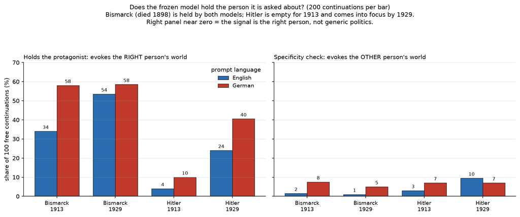

## The numbers (own domain, pooled over both prompts)

| model asked about | English | German |
| --- | --- | --- |
| Bismarck — Ranke 1913 | 34% | 58% |
| Bismarck — Ranke 1929 | 54% | 58% |
| Hitler — Ranke 1913 | 4% | 10% |
| Hitler — Ranke 1929 | 24% | 40% |

## Ranke 1913 holds Bismarck — verbatim (English)

- Who knows him personally, or who has read of his career. He stands today the foremost German statesman OF our time; a man whose fame will live through all time to come. He was born in Kniephofen, Prussia, November %, 1869. His
- This question which has been asked so frequently during the past few weeks and to such varied purposes, will doubtless be answered in various ways by different persons. It may seem a small matter for any one to know who this gentl
- And what was the part he played in the history of his time, and especially during these three years? What does "The Rise of Prussia" mean to us Americans today ? 2. A study should be made not only of this period but also of that i
- Is he a real person, or only an imaginary one. and what does he do in the world of politics and statesmanship? There is no such thing as the "Ottc Won" Of German history. He was not born until 1870, but his parents had long been
- Is he a man with the mind and personality Of his uncle, or Is there some mystery about him that makes 1t seem possible that he has no relation to the great statesman who founded Prussia. But II he really does have an ancestor like

## Ranke 1913 does not hold Hitler — verbatim (English)

- Who Is the man who has just been convicted of murder in New York and sentenced to death for killing two men with a hammer? He was an anarchist. 1t will be remembered that he, together with his brother. Gustave HINER, were arrested
- The word "Hillcr" is the name of a German engineer and scientist, who in recent years has made himself famous for his discovery Of process whereby diamonds can be produced from natural gas. The first great achievement was to find
- And what was the object of his mission to this country at this time? What are these men who have come here in large numbers and established themselves as socialists? They profess that they believe socialism will eventually succee
- He has been making some very interesting discovcries in the old world. and his latest story of discoveries made by him IN Russia Is one Of thrilling interest. The great Russian novelist, Gogol. whose death was recently announced,
- What is he? What does the name mean to American readers? In a recent number of The Worlds Work Mr.. Hiller's biography, by himself and his biographer. has been published in full, with many illus trations. He was born at Posen on

## Metric history (kept honest)

Two earlier attempts failed and are recorded so the choice can be judged. **Name-recurrence** (“does the surname reappear”) was confounded by style: Bismarck is called “the Prince” or “he”, so he scored as *not* sticking, while a confabulated “Mr. Hiller” scored as sticking. **TF-IDF cross-sample consistency** was a null (every cell ≈ 0.09) because shared newspaper style swamps the entity content. The on-domain rate above is what separates knowing from not knowing, and the specificity panel confirms it is the right person, not generic politics.

## The “same person/concept?” judgment — the exact prompt

The on-domain figure above is a keyword proxy (an upper bound). To decide, per continuation, whether the text is really about the same person — without my hand-adjudication — each of the 1,600 Hitler and Bismarck continuations was classified by an independent judge (`gemini-3.1-flash-lite`, temperature 0). This is the verbatim prompt, with `{desc}` filled by a one-line identity of the person and `{text}` by the continuation:

```
You are checking whether a short machine-generated passage is about one specific real historical person.

THE PERSON: {desc}

THE PASSAGE:
"""{text}"""

Does the passage describe THIS person — their life, role, deeds, or world — even if some details are wrong or invented?
Or has the name merely been attached to a different, invented, or unrelated person (or is the passage about something else)?

Answer with ONE word only:
SAME       — it is clearly meant to be this real person and fits their real identity/world (accept wrong dates or minor errors).
DIFFERENT  — the name is attached to a different or invented person, or the passage is about someone/something else.
UNCLEAR    — too little or too generic to decide.
```

The judge corroborates the keyword proxy and removes the hand-reading from the loop:

| asked about | English |  | German |  |
| --- | --- | --- | --- | --- |
|  | keyword | judge SAME | keyword | judge SAME |
| Bismarck — Ranke 1913 | 34% | 36% | 58% | 60% |
| Bismarck — Ranke 1929 | 54% | 43% | 58% | 62% |
| Hitler — Ranke 1913 | 4% | 5% | 10% | 6% |
| Hitler — Ranke 1929 | 24% | 26% | 40% | 36% |

Validation: of the eight English Hitler-1913 keyword “hits” that I had hand-read as false positives, the judge independently called seven DIFFERENT; the one it called SAME is a borderline “serious figure in the Socialist movement…” case. The judge’s Hitler-1913 rate (5–6%) is thus an upper estimate; the true rate is near zero.

## Postscript: “Adolf Hitler’s regime persecuted ___”

“Hitler’s regime” is a post-1933 thing — past the cutoff for *both* models, so neither can recall it. The tell is what they fill in. The real headline target (the Jews) is also period-plausible: a regime persecuting the Jews was ordinary pre-1913 news (Russian pogroms, the Dreyfus affair), so producing it is not evidence of knowing the Nazi regime. The discriminating target is one the regime really persecuted but that no 1913/1929 prior reaches — the **Bible Students** (Ernste Bibelforscher, the pre-1931 name for Jehovah’s Witnesses).

**Adolf Hitler's regime persecuted ___** — P(each ending):

| ending | Ranke 1913 | Ranke 1929 |
| --- | --- | --- |
| the Jews | 99% | 93% |
| the Socialists | 1% | 3% |
| the Catholics | 0% | 4% |
| the Freemasons | 0% | 0% |
| the Jehovah's Witnesses **← obscure, real** | 0% | 0% |
| the Bible Students **← obscure, real** | 0% | 0% |

**Adolf Hitlers Regime verfolgte ___** — P(each ending):

| ending | Ranke 1913 | Ranke 1929 |
| --- | --- | --- |
| die Juden | 69% | 27% |
| die Sozialisten | 3% | 38% |
| die Katholiken | 26% | 29% |
| die Freimaurer | 2% | 6% |
| die Zeugen Jehovas **← obscure, real** | 0% | 0% |
| die Ernsten Bibelforscher **← obscure, real** | 0% | 0% |

## Placebo control: is “persecuted the Jews” specific, or a frame default?

Swap Hitler for leaders who persecuted no Jews — Winston Churchill, and Chancellor Bethmann-Hollweg (1909–1917, a real figure in both corpora) — and read the same P(“persecuted the Jews”) in three languages.

**Ranke 1913** — P(“persecuted the Jews”):

| leader | English | German | French |
| --- | --- | --- | --- |
| Adolf Hitler | 85% | 51% | 95% |
| Winston Churchill | 36% | 34% | 23% |
| Bethmann-Hollweg (Chancellor 1909–17; no Jewish persecution) | 89% | 39% | 88% |

**Ranke 1929** — P(“persecuted the Jews”):

| leader | English | German | French |
| --- | --- | --- | --- |
| Adolf Hitler | 92% | 26% | 88% |
| Winston Churchill | 71% | 36% | 37% |
| Bethmann-Hollweg (Chancellor 1909–17; no Jewish persecution) | 81% | 46% | 75% |

The completion “persecuted the Jews” is largely a **frame default**, not knowledge: in English and French, Bethmann-Hollweg — who persecuted no one — scores as high as Hitler (≈ 80–90%). The default is weaker for the British “Churchill” and weakest in German, which spreads its guess across period-salient targets (Kulturkampf Catholics, the anti-socialist tradition) and, for the 1929 Hitler, toward the Socialists it knows were his real enemies. So German is **lower**, not higher — the opposite of a German antisemitic default. (Cross-language absolute levels are affected by how each object set tokenizes; the clean test is Hitler vs the placebos *within* a language, where Bethmann ≈ Hitler in EN and FR.) The one invariant across every leader and language: zero weight on the obscure-but-real Bible Students — the target that would require actual regime knowledge.